# SarcasmDetection_submission

```python
import pandas as pd
import numpy as np
import matplotlib.pyplot as plt
import seaborn as sns
from sklearn.model_selection import train_test_split
from sklearn.preprocessing import LabelEncoder
import keras
from keras.models import Model
from keras.layers import LSTM, Activation, Dense, Dropout, Input, Embedding,Bidirectional,GRU
from keras.optimizers import RMSprop
from keras.preprocessing.text import Tokenizer
from keras.preprocessing import sequence
from keras.utils import to_categorical
from keras.callbacks import EarlyStopping
from sklearn.feature_extraction.text import CountVectorizer
from keras.preprocessing.text import Tokenizer
from keras.preprocessing.sequence import pad_sequences
from keras.models import Sequential
from keras.layers import Dense, Embedding, LSTM, SpatialDropout1D
from sklearn.model_selection import train_test_split
from keras.utils.np_utils import to_categorical
%matplotlib inline
import os
import re
```

### Analyzing Data

```python
#removing column width to observe haedline
pd.set_option('display.max_colwidth', None)
```

```python
df = pd.read_json("data/Sarcasm_Headlines_Dataset.json", lines=True)
df.head()
```

|  | article_link | headline | is_sarcastic |
| --- | --- | --- | --- |
| 0 | https://www.huffingtonpost.com/entry/versace-black-code_us_5861fbefe4b0de3a08f600d5 | former versace store clerk sues over secret 'black code' for minority shoppers | 0 |
| 1 | https://www.huffingtonpost.com/entry/roseanne-revival-review_us_5ab3a497e4b054d118e04365 | the 'roseanne' revival catches up to our thorny political mood, for better and worse | 0 |
| 2 | https://local.theonion.com/mom-starting-to-fear-son-s-web-series-closest-thing-she-1819576697 | mom starting to fear son's web series closest thing she will have to grandchild | 1 |
| 3 | https://politics.theonion.com/boehner-just-wants-wife-to-listen-not-come-up-with-alt-1819574302 | boehner just wants wife to listen, not come up with alternative debt-reduction ideas | 1 |
| 4 | https://www.huffingtonpost.com/entry/jk-rowling-wishes-snape-happy-birthday_us_569117c4e4b0cad15e64fdcb | j.k. rowling wishes snape happy birthday in the most magical way | 0 |

```python
df.info()
```

```
<class 'pandas.core.frame.DataFrame'>
RangeIndex: 26709 entries, 0 to 26708
Data columns (total 3 columns):
 #   Column        Non-Null Count  Dtype
---  ------        --------------  -----
 0   article_link  26709 non-null  object
 1   headline      26709 non-null  object
 2   is_sarcastic  26709 non-null  int64
dtypes: int64(1), object(2)
memory usage: 626.1+ KB
```

- Target colum - is_sarcastic having values as 0 and 1
- Headline column carries the headline of the article, these characters hold importent words that distinguishes the sarcastic words and serious words in headlines
- Article_link column carries the link for the article, link details doesnt contain much additional info compared to headline but just the repeat of words to represent the link
- Total 26,709 data points available

```python
df.isna().sum()
```

```
article_link    0
headline        0
is_sarcastic    0
dtype: int64
```

- No null values found
- Removing the article link column as its not adding value to dataframe

```python
del df['article_link']
```

```python
df.info()
```

```
<class 'pandas.core.frame.DataFrame'>
RangeIndex: 26709 entries, 0 to 26708
Data columns (total 2 columns):
 #   Column        Non-Null Count  Dtype
---  ------        --------------  -----
 0   headline      26709 non-null  object
 1   is_sarcastic  26709 non-null  int64
dtypes: int64(1), object(1)
memory usage: 417.5+ KB
```

#### Preprocessing and Visualization

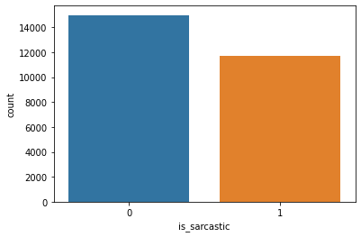

```python
sns.countplot(df['is_sarcastic']);
```

```python
df.is_sarcastic.value_counts()
```

```
0    14985
1    11724
Name: is_sarcastic, dtype: int64
```

- We can notice we have more of non sracastic data points compared to sarcastic
- This is still not a very significant difference as we have a wide data set

```python
df.sample(10)
```

|  | headline | is_sarcastic |
| --- | --- | --- |
| 11217 | boise homemaker bows toward mecca just to see what it's like | 1 |
| 21124 | the trump-russia story has only just begun (to explode) | 0 |
| 1304 | black friday 2015: the best deals around the web | 0 |
| 22945 | paleontologists determine dinosaurs were killed by someone they trusted | 1 |
| 21931 | child unaware just how many of his toys intended to steer him away from homosexuality | 1 |
| 19701 | chicago west makes her debut in kylie jenner's baby announcement | 0 |
| 22305 | how model valerie ramsey is opening new worlds for older women | 0 |
| 9118 | eccentric man introduces new sweater to closet pals colonel coat and captain blazer | 1 |
| 10629 | 5 money lessons to teach our daughters | 0 |
| 6189 | polish and irish soccer fans shame hooligans with heartwarming embrace | 0 |

###### Cleaning Headline column

```python
df['headline'] = df['headline'].apply(lambda x: x.lower())
df['headline'] = df['headline'].apply((lambda x: re.sub('[^a-zA-z0-9\s]','',x)))
```

###### Setting up tokenizer and max words we will be using to speed up the model building process

```python
for idx,row in df.iterrows():
    row[0] = row[0].replace('rt',' ')

max_fatures = 2000
tokenizer = Tokenizer(num_words=max_fatures, split=' ')
tokenizer.fit_on_texts(df['headline'].values)
X = tokenizer.texts_to_sequences(df['headline'].values)
X = pad_sequences(X)
```

###### Splitting data into train and test sets

```python
Y = pd.get_dummies(df['is_sarcastic']).values
X_train, X_test, Y_train, Y_test = train_test_split(X,Y, test_size = 0.33, random_state = 42)
print(X_train.shape,Y_train.shape)
print(X_test.shape,Y_test.shape)
```

```
(17895, 29) (17895, 2)
(8814, 29) (8814, 2)
```

##### LSTM + RNN model

```python
embed_dim = 128
lstm_out = 196

model = Sequential()
model.add(Embedding(max_fatures, embed_dim,input_length = X.shape[1]))
model.add(SpatialDropout1D(0.4))
model.add(LSTM(lstm_out, dropout=0.2, recurrent_dropout=0.2))
model.add(Dense(2,activation='softmax'))
model.compile(loss = 'categorical_crossentropy', optimizer='adam',metrics = ['accuracy'])
print(model.summary())
```

```
Model: "sequential_1"
_________________________________________________________________
Layer (type)                 Output Shape              Param #
=================================================================
embedding_1 (Embedding)      (None, 29, 128)           256000
_________________________________________________________________
spatial_dropout1d_1 (Spatial (None, 29, 128)           0
_________________________________________________________________
lstm_1 (LSTM)                (None, 196)               254800
_________________________________________________________________
dense_1 (Dense)              (None, 2)                 394
=================================================================
Total params: 511,194
Trainable params: 511,194
Non-trainable params: 0
_________________________________________________________________
None
```

```python
batch_size = 32
history = model.fit(X_train, Y_train, epochs = 25, batch_size=batch_size, verbose = 2)
```

```
 - 40s - loss: 0.4498 - accuracy: 0.7822
 - 42s - loss: 0.3371 - accuracy: 0.8553
 - 44s - loss: 0.3024 - accuracy: 0.8723
 - 43s - loss: 0.2774 - accuracy: 0.8824
 - 42s - loss: 0.2575 - accuracy: 0.8932
 - 42s - loss: 0.2351 - accuracy: 0.9016
 - 43s - loss: 0.2216 - accuracy: 0.9071
 - 43s - loss: 0.2012 - accuracy: 0.9184
 - 42s - loss: 0.1884 - accuracy: 0.9220
 - 42s - loss: 0.1765 - accuracy: 0.9277
 - 43s - loss: 0.1599 - accuracy: 0.9360
 - 43s - loss: 0.1471 - accuracy: 0.9419
 - 43s - loss: 0.1358 - accuracy: 0.9459
 - 44s - loss: 0.1263 - accuracy: 0.9510
 - 64s - loss: 0.1166 - accuracy: 0.9525
 - 65s - loss: 0.1085 - accuracy: 0.9575
 - 77s - loss: 0.1029 - accuracy: 0.9595
 - 75s - loss: 0.0970 - accuracy: 0.9612
 - 72s - loss: 0.0871 - accuracy: 0.9668
 - 72s - loss: 0.0768 - accuracy: 0.9708
 - 74s - loss: 0.0742 - accuracy: 0.9713
 - 72s - loss: 0.0712 - accuracy: 0.9726
 - 72s - loss: 0.0640 - accuracy: 0.9748
 - 72s - loss: 0.0627 - accuracy: 0.9763
 - 72s - loss: 0.0620 - accuracy: 0.9758
```

```python
validation_size = 1500

X_validate = X_test[-validation_size:]
Y_validate = Y_test[-validation_size:]
X_test = X_test[:-validation_size]
Y_test = Y_test[:-validation_size]
score,acc = model.evaluate(X_test, Y_test, verbose = 2, batch_size = batch_size)
print("score: %.2f" % (score))
print("acc: %.2f" % (acc))
```

```
score: 0.97
acc: 0.82
```

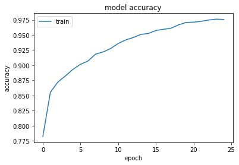

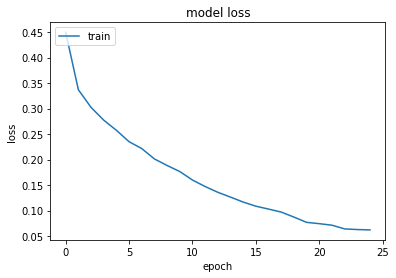

```python
# summarize history for accuracy
plt.plot(history.history['accuracy'])
#plt.plot(history.history['val_acc'])
plt.title('model accuracy')
plt.ylabel('accuracy')
plt.xlabel('epoch')
plt.legend(['train', 'test'], loc='upper left')
plt.show()
plt.savefig('model_accuracy.png')
# summarize history for loss
plt.plot(history.history['loss'])
#plt.plot(history.history['val_loss'])
plt.title('model loss')
plt.ylabel('loss')
plt.xlabel('epoch')
plt.legend(['train', 'test'], loc='upper left')
plt.show()
plt.savefig('model_loss.png')
```

```python
pos_cnt, neg_cnt, pos_correct, neg_correct = 0, 0, 0, 0
for x in range(len(X_validate)):

    result = model.predict(X_validate[x].reshape(1,X_test.shape[1]),batch_size=1,verbose = 2)[0]

    if np.argmax(result) == np.argmax(Y_validate[x]):
        if np.argmax(Y_validate[x]) == 0:
            neg_correct += 1
        else:
            pos_correct += 1

    if np.argmax(Y_validate[x]) == 0:
        neg_cnt += 1
    else:
        pos_cnt += 1



print("Sarcasm_acc", pos_correct/pos_cnt*100, "%")
print("Non-Sarcasm_acc", neg_correct/neg_cnt*100, "%")
```

```
Sarcasm_acc 80.09049773755656 %
Non-Sarcasm_acc 84.58781362007169 %
```

```python
headline = ['Chowkidar hi chor hai']
headline = tokenizer.texts_to_sequences(headline)
headline = pad_sequences(headline, maxlen=29, dtype='int32', value=0)

sentiment = model.predict(headline,batch_size=1,verbose = 2)[0]
if(np.argmax(sentiment) == 0):
    print("Non-sarcastic")
elif (np.argmax(sentiment) == 1):
    print("Sarcasm")
```

```
Sarcasm
```

```python
headline = ['unaware sons eats lipstick as lunch']
headline = tokenizer.texts_to_sequences(headline)
headline = pad_sequences(headline, maxlen=29, dtype='int32', value=0)

sentiment = model.predict(headline,batch_size=1,verbose = 2)[0]
if(np.argmax(sentiment) == 0):
    print("Non-sarcastic")
elif (np.argmax(sentiment) == 1):
    print("Sarcasm")
```

```
Sarcasm
```

```python
# serialize model to JSON
model_json = model.to_json()
with open("model2.json", "w") as json_file:
    json_file.write(model_json)
# serialize weights to HDF5
model.save_weights("model2.h5")
```

##### Some more data preparation steps

#### Removing stop words

```python
from nltk.corpus import stopwords
from string import punctuation
import re,string,unicodedata

stop = set(stopwords.words('english'))
punctuation = list(string.punctuation)
stop.update(punctuation)
```

```python
#Removing the stopwords from text
def remove_stopwords(text):
    final_text = []
    for i in text.split():
        if i.strip().lower() not in stop:
            final_text.append(i.strip())
    return " ".join(final_text)
```

```python
df['headline'] = df['headline'].apply(remove_stopwords)
df['headline'] = df['headline'].apply(lambda x: x.lower())
df['headline'] = df['headline'].apply((lambda x: re.sub('[^a-zA-z0-9\s]','',x)))
```

```python
words = []
for i in df.headline.values:
    words.append(i.split())
words[:5]
```

```
[['former',
  'versace',
  'store',
  'clerk',
  'sues',
  'secret',
  'black',
  'code',
  'minority',
  'shoppers'],
 ['roseanne',
  'revival',
  'catches',
  'thorny',
  'political',
  'mood',
  'better',
  'worse'],
 ['mom',
  'starting',
  'fear',
  'sons',
  'web',
  'series',
  'closest',
  'thing',
  'grandchild'],
 ['boehner',
  'wants',
  'wife',
  'listen',
  'come',
  'alternative',
  'debtreduction',
  'ideas'],
 ['jk', 'rowling', 'wishes', 'snape', 'happy', 'birthday', 'magical', 'way']]
```

```python
!pip install gensim
```

```python
import gensim
#Dimension of vectors we are generating
EMBEDDING_DIM = 200

#Creating Word Vectors by Word2Vec Method (takes time...)
w2v_model = gensim.models.Word2Vec(sentences = words , vector_size=EMBEDDING_DIM , window = 5 , min_count = 1)
```

```python
#vocab size
#https://github.com/RaRe-Technologies/gensim/wiki/Migrating-from-Gensim-3.x-to-4
vocab_len = len(w2v_model.wv)
print(vocab_len)
```

```
28257
```

```python
from keras.preprocessing import text, sequence

#tokenizer = text.Tokenizer(num_words=max_fatures, split=' ') #keeping same as earier will update later
tokenizer = text.Tokenizer(num_words=28000, split=' ')
tokenizer.fit_on_texts(words)
tokenized_train = tokenizer.texts_to_sequences(words)
x = sequence.pad_sequences(tokenized_train, maxlen = 20)
```

```python
vocab_size = len(tokenizer.word_index) + 1
```

```python
# Function to create weight matrix from word2vec gensim model
def get_weight_matrix(model, vocab):
    vocab_size = len(vocab) + 1
    weight_matrix = np.zeros((vocab_size, EMBEDDING_DIM))
    for word, i in vocab.items():
        weight_matrix[i] = model.wv[word]
    return weight_matrix
```

```python
embedding_vectors = get_weight_matrix(w2v_model, tokenizer.word_index)
```

```python
#Defining Neural Network
model = Sequential()
#Non-trainable embeddidng layer
model.add(Embedding(vocab_size, output_dim=EMBEDDING_DIM, weights=[embedding_vectors], input_length=20, trainable=True))
#LSTM
model.add(Bidirectional(LSTM(units=128 , recurrent_dropout = 0.3 , dropout = 0.3,return_sequences = True)))
model.add(Bidirectional(GRU(units=32 , recurrent_dropout = 0.1 , dropout = 0.1)))
model.add(Dense(1, activation='sigmoid'))
model.compile(optimizer=keras.optimizers.Adam(lr = 0.01), loss='binary_crossentropy', metrics=['acc'])

del embedding_vectors
```

```python
model.summary()
```

```
Model: "sequential_2"
_________________________________________________________________
Layer (type)                 Output Shape              Param #
=================================================================
embedding_2 (Embedding)      (None, 20, 200)           5651600
_________________________________________________________________
bidirectional_1 (Bidirection (None, 20, 256)           336896
_________________________________________________________________
bidirectional_2 (Bidirection (None, 64)                55488
_________________________________________________________________
dense_2 (Dense)              (None, 1)                 65
=================================================================
Total params: 6,044,049
Trainable params: 6,044,049
Non-trainable params: 0
_________________________________________________________________
```

```python
x_train, x_test, y_train, y_test = train_test_split(x, df.is_sarcastic , test_size = 0.3 , random_state = 0)
```

```python
history = model.fit(x_train, y_train, batch_size = 128 , validation_data = (x_test,y_test) , epochs = 25)
```

```
Train on 18696 samples, validate on 8013 samples
```

```python
print("Accuracy of the model on Training Data is - " , model.evaluate(x_train,y_train)[1]*100)
print("Accuracy of the model on Testing Data is - " , model.evaluate(x_test,y_test)[1]*100)
```

```
Accuracy of the model on Training Data is -  99.96790885925293
Accuracy of the model on Testing Data is -  76.60052180290222
```

```python
import gc
gc.collect()
```

```
41460
```

```python
from sklearn.model_selection import train_test_split

train_sentences, val_sentences, train_labels, val_labels = train_test_split(df['headline'], df['is_sarcastic'], test_size=0.2, random_state=0)

print(train_sentences.shape)
print(val_sentences.shape)
print(train_labels.shape)
print(val_labels.shape)
```

```
(21367,)
(5342,)
(21367,)
(5342,)
```

```python
# Tokenize and pad
vocab_size = 10000
oov_token = '<00V>'
max_length = 120
padding_type = 'post'
trunc_type = 'post'
embedding_dim = 16
num_epochs = 10
```

```python
tokenizer = Tokenizer(num_words=vocab_size, oov_token=oov_token)
tokenizer.fit_on_texts(train_sentences)
word_index = tokenizer.word_index

train_sequences = tokenizer.texts_to_sequences(train_sentences)
train_padded = pad_sequences(train_sequences, maxlen=max_length, padding=padding_type, truncating=trunc_type)

val_sequences = tokenizer.texts_to_sequences(val_sentences)
val_padded = pad_sequences(val_sequences, maxlen=max_length, padding=padding_type, truncating=trunc_type)
```

#### Dense layer with GlobalAveragePooling

```python
import tensorflow as tf
model = tf.keras.models.Sequential([
    tf.keras.layers.Embedding(vocab_size, embedding_dim, input_length=max_length),
    tf.keras.layers.GlobalAveragePooling1D(),
    tf.keras.layers.Dense(24, activation='relu'),
    tf.keras.layers.Dense(1, activation='sigmoid')
])

model.compile(loss='binary_crossentropy',optimizer='adam', metrics=['accuracy'])
model.summary()
history = model.fit(train_padded,
                    train_labels,
                    validation_data=(val_padded, val_labels),
                    epochs=num_epochs,
                    verbose=2)
```

```
Model: "sequential"
_________________________________________________________________
Layer (type)                 Output Shape              Param #
=================================================================
embedding (Embedding)        (None, 120, 16)           160000
_________________________________________________________________
global_average_pooling1d (Gl (None, 16)                0
_________________________________________________________________
dense (Dense)                (None, 24)                408
_________________________________________________________________
dense_1 (Dense)              (None, 1)                 25
=================================================================
Total params: 160,433
Trainable params: 160,433
Non-trainable params: 0
_________________________________________________________________
Train on 21367 samples, validate on 5342 samples
21367/21367 - 3s - loss: 0.6828 - accuracy: 0.5606 - val_loss: 0.6712 - val_accuracy: 0.5631
21367/21367 - 3s - loss: 0.6149 - accuracy: 0.6600 - val_loss: 0.5546 - val_accuracy: 0.7507
21367/21367 - 2s - loss: 0.4637 - accuracy: 0.8026 - val_loss: 0.4624 - val_accuracy: 0.7909
21367/21367 - 2s - loss: 0.3706 - accuracy: 0.8464 - val_loss: 0.4300 - val_accuracy: 0.7954
21367/21367 - 2s - loss: 0.3202 - accuracy: 0.8695 - val_loss: 0.4201 - val_accuracy: 0.8040
21367/21367 - 2s - loss: 0.2874 - accuracy: 0.8853 - val_loss: 0.4241 - val_accuracy: 0.8049
21367/21367 - 3s - loss: 0.2646 - accuracy: 0.8947 - val_loss: 0.4266 - val_accuracy: 0.8044
21367/21367 - 2s - loss: 0.2419 - accuracy: 0.9032 - val_loss: 0.4291 - val_accuracy: 0.8063
21367/21367 - 3s - loss: 0.2245 - accuracy: 0.9121 - val_loss: 0.4417 - val_accuracy: 0.8072
21367/21367 - 2s - loss: 0.2099 - accuracy: 0.9175 - val_loss: 0.4541 - val_accuracy: 0.8064
```

#### Dense layer with Flatten

```python
model2 = tf.keras.models.Sequential([
    tf.keras.layers.Embedding(vocab_size, embedding_dim, input_length=max_length),
    tf.keras.layers.Flatten(),
    tf.keras.layers.Dense(24, activation='relu'),
    tf.keras.layers.Dense(1, activation='sigmoid')
])

model2.compile(loss='binary_crossentropy',optimizer='adam', metrics=['accuracy'])
model2.summary()
history_flatten = model2.fit(train_padded,
                    train_labels,
                    validation_data=(val_padded, val_labels),
                    epochs=num_epochs,
                    verbose=2)
```

```
Model: "sequential_1"
_________________________________________________________________
Layer (type)                 Output Shape              Param #
=================================================================
embedding_1 (Embedding)      (None, 120, 16)           160000
_________________________________________________________________
flatten (Flatten)            (None, 1920)              0
_________________________________________________________________
dense_2 (Dense)              (None, 24)                46104
_________________________________________________________________
dense_3 (Dense)              (None, 1)                 25
=================================================================
Total params: 206,129
Trainable params: 206,129
Non-trainable params: 0
_________________________________________________________________
Train on 21367 samples, validate on 5342 samples
21367/21367 - 4s - loss: 0.5233 - accuracy: 0.7223 - val_loss: 0.4006 - val_accuracy: 0.8096
21367/21367 - 2s - loss: 0.2679 - accuracy: 0.8900 - val_loss: 0.4033 - val_accuracy: 0.8209
21367/21367 - 2s - loss: 0.1443 - accuracy: 0.9491 - val_loss: 0.4849 - val_accuracy: 0.8139
21367/21367 - 2s - loss: 0.0682 - accuracy: 0.9787 - val_loss: 0.5851 - val_accuracy: 0.8100
21367/21367 - 2s - loss: 0.0296 - accuracy: 0.9926 - val_loss: 0.6945 - val_accuracy: 0.8040
21367/21367 - 2s - loss: 0.0132 - accuracy: 0.9971 - val_loss: 0.8043 - val_accuracy: 0.8057
21367/21367 - 2s - loss: 0.0067 - accuracy: 0.9987 - val_loss: 0.8923 - val_accuracy: 0.8064
21367/21367 - 2s - loss: 0.0040 - accuracy: 0.9991 - val_loss: 0.9327 - val_accuracy: 0.8010
21367/21367 - 3s - loss: 0.0027 - accuracy: 0.9995 - val_loss: 1.0294 - val_accuracy: 0.8053
21367/21367 - 2s - loss: 0.0021 - accuracy: 0.9994 - val_loss: 1.0275 - val_accuracy: 0.7975
```

#### Single Bidirectional LSTM layer

```python
model_lstm = tf.keras.models.Sequential([
    tf.keras.layers.Embedding(vocab_size, embedding_dim, input_length=max_length),
    tf.keras.layers.Bidirectional(tf.keras.layers.LSTM(32)),
    tf.keras.layers.Dense(24, activation='relu'),
    tf.keras.layers.Dense(1, activation='sigmoid')
])

model_lstm.compile(loss='binary_crossentropy',optimizer='adam', metrics=['accuracy'])
model_lstm.summary()
history_lstm = model_lstm.fit(train_padded,
                    train_labels,
                    validation_data=(val_padded, val_labels),
                    epochs=num_epochs,
                    verbose=2)
```

```
Model: "sequential_2"
_________________________________________________________________
Layer (type)                 Output Shape              Param #
=================================================================
embedding_2 (Embedding)      (None, 120, 16)           160000
_________________________________________________________________
bidirectional (Bidirectional (None, 64)                12544
_________________________________________________________________
dense_4 (Dense)              (None, 24)                1560
_________________________________________________________________
dense_5 (Dense)              (None, 1)                 25
=================================================================
Total params: 174,129
Trainable params: 174,129
Non-trainable params: 0
_________________________________________________________________
Train on 21367 samples, validate on 5342 samples
21367/21367 - 48s - loss: 0.4970 - accuracy: 0.7451 - val_loss: 0.4066 - val_accuracy: 0.8107
21367/21367 - 45s - loss: 0.2915 - accuracy: 0.8756 - val_loss: 0.4111 - val_accuracy: 0.8102
21367/21367 - 50s - loss: 0.1956 - accuracy: 0.9219 - val_loss: 0.4602 - val_accuracy: 0.8094
21367/21367 - 49s - loss: 0.1286 - accuracy: 0.9521 - val_loss: 0.5751 - val_accuracy: 0.8025
21367/21367 - 56s - loss: 0.0884 - accuracy: 0.9693 - val_loss: 0.6713 - val_accuracy: 0.7905
21367/21367 - 83s - loss: 0.0642 - accuracy: 0.9781 - val_loss: 0.7870 - val_accuracy: 0.7903
21367/21367 - 61s - loss: 0.0443 - accuracy: 0.9856 - val_loss: 0.9909 - val_accuracy: 0.7873
21367/21367 - 58s - loss: 0.0340 - accuracy: 0.9893 - val_loss: 1.0115 - val_accuracy: 0.7877
21367/21367 - 44s - loss: 0.0247 - accuracy: 0.9918 - val_loss: 1.1957 - val_accuracy: 0.7815
21367/21367 - 39s - loss: 0.0189 - accuracy: 0.9941 - val_loss: 1.3387 - val_accuracy: 0.7800
```

#### Multi layer bidirectional lstm

```python
model_mul_lstm = tf.keras.models.Sequential([
    tf.keras.layers.Embedding(vocab_size, embedding_dim, input_length=max_length),
    tf.keras.layers.Bidirectional(tf.keras.layers.LSTM(64, return_sequences=True)),
    tf.keras.layers.Bidirectional(tf.keras.layers.LSTM(32)),
    tf.keras.layers.Dense(24, activation='relu'),
    tf.keras.layers.Dense(1, activation='sigmoid')
])

model_mul_lstm.compile(loss='binary_crossentropy',optimizer='adam', metrics=['accuracy'])
model_mul_lstm.summary()
history_mul_lstm = model_mul_lstm.fit(train_padded,
                    train_labels,
                    validation_data=(val_padded, val_labels),
                    epochs=num_epochs,
                    verbose=2)
```

```
Model: "sequential_3"
_________________________________________________________________
Layer (type)                 Output Shape              Param #
=================================================================
embedding_3 (Embedding)      (None, 120, 16)           160000
_________________________________________________________________
bidirectional_1 (Bidirection (None, 120, 128)          41472
_________________________________________________________________
bidirectional_2 (Bidirection (None, 64)                41216
_________________________________________________________________
dense_6 (Dense)              (None, 24)                1560
_________________________________________________________________
dense_7 (Dense)              (None, 1)                 25
=================================================================
Total params: 244,273
Trainable params: 244,273
Non-trainable params: 0
_________________________________________________________________
Train on 21367 samples, validate on 5342 samples
21367/21367 - 113s - loss: 0.5168 - accuracy: 0.7304 - val_loss: 0.4108 - val_accuracy: 0.8048
21367/21367 - 108s - loss: 0.3082 - accuracy: 0.8665 - val_loss: 0.4147 - val_accuracy: 0.8137
21367/21367 - 107s - loss: 0.2165 - accuracy: 0.9143 - val_loss: 0.4689 - val_accuracy: 0.8091
21367/21367 - 107s - loss: 0.1432 - accuracy: 0.9460 - val_loss: 0.5345 - val_accuracy: 0.8053
21367/21367 - 111s - loss: 0.1180 - accuracy: 0.9603 - val_loss: 0.5009 - val_accuracy: 0.7632
21367/21367 - 106s - loss: 0.1983 - accuracy: 0.9208 - val_loss: 0.6039 - val_accuracy: 0.8019
21367/21367 - 105s - loss: 0.0910 - accuracy: 0.9675 - val_loss: 0.7462 - val_accuracy: 0.7918
21367/21367 - 105s - loss: 0.0553 - accuracy: 0.9813 - val_loss: 0.7927 - val_accuracy: 0.7885
21367/21367 - 105s - loss: 0.0410 - accuracy: 0.9869 - val_loss: 0.9656 - val_accuracy: 0.7888
21367/21367 - 104s - loss: 0.0272 - accuracy: 0.9921 - val_loss: 1.0694 - val_accuracy: 0.7870
```

#### Data Prep with GLove 200d

```python
df = pd.read_json("data/Sarcasm_Headlines_Dataset.json", lines=True)
```

```python
import re

def decontracted(phrase):
    phrase=str(phrase)
    # specific
    phrase = re.sub(r"won\'t", "will not", phrase)
    phrase = re.sub(r"can\'t", "can not", phrase)

    # general
    phrase = re.sub(r"n\'t", " not", phrase)
    phrase = re.sub(r"\'re", " are", phrase)
    phrase = re.sub(r"\'s", " is", phrase)
    phrase = re.sub(r"\'d", " would", phrase)
    phrase = re.sub(r"\'ll", " will", phrase)
    phrase = re.sub(r"\'t", " not", phrase)
    phrase = re.sub(r"\'ve", " have", phrase)
    phrase = re.sub(r"\'m", " am", phrase)
    return phrase
```

```python
import spacy
#https://spacy.io/usage/models
nlp = spacy.load('en_core_web_sm')
def preprocessing(text):
  text = text.replace('#','')
  text = decontracted(text)
  text = re.sub('\S*@\S*\s?','',text)
  text = re.sub('http[s]?:(?:[a-zA-Z]|[0-9]|[$-_@.&+]|[!*\(\),]|(?:%[0-9a-fA-F][0-9a-fA-F]))+','',text)

  token=[]
  result=''
  text = re.sub('[^A-z]', ' ',text.lower())

  text = nlp(text)
  for t in text:
    if not t.is_stop and len(t)>2:
      token.append(t.lemma_)
  result = ' '.join([i for i in token])

  return result.strip()
```

```python
#df.text = df.headline.apply(lambda x : preprocessing(x))
```

```python
df['headline'] = df['headline'].apply(lambda x: x.lower())
df['headline'] = df['headline'].apply((lambda x: re.sub('[^a-zA-z0-9\s]','',x)))
```

```python
from nltk.tokenize import word_tokenize
from tqdm import tqdm
from nltk.corpus import stopwords
stop=set(stopwords.words('english'))
def create_corpus(df):
    corpus=[]
    for tweet in tqdm(df['headline']):
        words=[word.lower() for word in word_tokenize(tweet) if((word.isalpha()==1) & (word not in stop))]
        corpus.append(words)
    return corpus
```

```python
corpus=create_corpus(df)
```

```python
import numpy as np
embedding_dict={}
with open('data/glove.6B.200d.txt','r',encoding='utf8') as f:
    for line in f:
        values=line.split()
        word=values[0]
        vectors=np.asarray(values[1:],'float32')
        embedding_dict[word]=vectors
f.close()
```

```python
from keras.preprocessing.text import Tokenizer
from keras.preprocessing.sequence import pad_sequences
MAX_LEN=40
tokenizer_obj=Tokenizer()
tokenizer_obj.fit_on_texts(corpus)
sequences=tokenizer_obj.texts_to_sequences(corpus)

tweet_pad=pad_sequences(sequences,maxlen=MAX_LEN,truncating='post',padding='post')
```

```python
word_index=tokenizer_obj.word_index
print('Number of unique words:',len(word_index))
```

```
Number of unique words: 27418
```

```python
num_words=len(word_index)+1
embedding_matrix=np.zeros((num_words,200))

for word,i in tqdm(word_index.items()):
    if i > num_words:
        continue

    emb_vec=embedding_dict.get(word)
    if emb_vec is not None:
        embedding_matrix[i]=emb_vec
```

#### Single layer LSTM

```python
from keras.models import Sequential
from keras.layers import Embedding,LSTM,Dense,SpatialDropout1D,Dropout
from keras.initializers import Constant
from keras.optimizers import Adam
model=Sequential()

embedding=Embedding(num_words,200,embeddings_initializer=Constant(embedding_matrix),
                   input_length=MAX_LEN,trainable=False)

model.add(embedding)
model.add(SpatialDropout1D(0.2))
model.add(LSTM(64,dropout=0.2, recurrent_dropout=0.2))


model.add(Dense(1, activation='sigmoid'))



optimzer=Adam(learning_rate=0.001)

model.compile(loss='binary_crossentropy',optimizer=optimzer,metrics=['accuracy'])
model.summary()
```

```
Model: "sequential_3"
_________________________________________________________________
Layer (type)                 Output Shape              Param #
=================================================================
embedding_3 (Embedding)      (None, 40, 200)           5483800
_________________________________________________________________
spatial_dropout1d_2 (Spatial (None, 40, 200)           0
_________________________________________________________________
lstm_3 (LSTM)                (None, 64)                67840
_________________________________________________________________
dense_3 (Dense)              (None, 1)                 65
=================================================================
Total params: 5,551,705
Trainable params: 67,905
Non-trainable params: 5,483,800
_________________________________________________________________
```

```python
from keras.callbacks import ModelCheckpoint,EarlyStopping
filepath="weights-model.hdf5"
checkpoint = ModelCheckpoint(filepath, monitor='val_accuracy', verbose=1, save_best_only=True, mode='max')
es = EarlyStopping(monitor='val_accuracy', mode='max', verbose=1, patience=30)
callbacks_list = [checkpoint,es]
```

```python
tweet=df.iloc[:,:]
X=tweet_pad[:tweet.shape[0]]
```

```python
from sklearn.model_selection import train_test_split
X_train,X_test,y_train,y_test=train_test_split(X,tweet['is_sarcastic'].values,test_size=0.2)
print('Shape of train',X_train.shape)
print("Shape of Validation ",X_test.shape)
```

```
Shape of train (21367, 40)
Shape of Validation  (5342, 40)
```

```python
history=model.fit(X_train,y_train,batch_size=100,epochs=25,validation_data=(X_test,y_test),verbose=1)
```

```
Train on 21367 samples, validate on 5342 samples
```

```python
#history=model.fit(X_train,y_train,batch_size=100,epochs=100,validation_data=(X_test,y_test),verbose=1)
```

```python
#headline = ['\'nice to meet you,\' coworkers tell new employee they\'ve studied online for hours']
#headline = pd.DataFrame(headline)
#headline = preprocessing(headline)

headline = ['\'nice to meet you,\' coworkers tell new employee they\'ve studied online for hours']
sequences=tokenizer_obj.texts_to_sequences(headline)

headline=pad_sequences(sequences,maxlen=MAX_LEN,truncating='post',padding='post')

sentiment = model.predict(headline,batch_size=1,verbose = 2)[0]
if(sentiment < 0.45):
    print("Non-sarcastic")
else:
    print("Sarcasm")
```

```
Sarcasm
```

```python
sentiment
```

```
array([0.9602281], dtype=float32)
```

```python
#headline = ['\'nice to meet you,\' coworkers tell new employee they\'ve studied online for hours']
#headline = pd.DataFrame(headline)
#headline = preprocessing(headline)

headline = ['dog is smoking hot']
sequences=tokenizer_obj.texts_to_sequences(headline)

headline=pad_sequences(sequences,maxlen=MAX_LEN,truncating='post',padding='post')

sentiment = model.predict(headline,batch_size=1,verbose = 2)[0]
if(sentiment < 0.45):
    print("Non-sarcastic")
else:
    print("Sarcasm")
```

```
Non-sarcastic
```

```python
sentiment
```

```
array([0.2567967], dtype=float32)
```

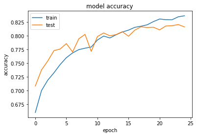

```python
plt.plot(history.history['accuracy'])
plt.plot(history.history['val_accuracy'])
plt.title('model accuracy')
plt.ylabel('accuracy')
plt.xlabel('epoch')
plt.legend(['train', 'test'], loc='upper left')
plt.show()
```

```python
from sklearn.externals import joblib

# Save the model as a pickle in a file

joblib.dump(model, 'model_embd_2.pkl')
```

```
['model_embd_2.pkl']
```

#### Multi layer bidirectional lstm

```python
model2=Sequential()

embedding=Embedding(num_words,200,embeddings_initializer=Constant(embedding_matrix),
                   input_length=MAX_LEN,trainable=False)

model2.add(embedding)
model2.add(SpatialDropout1D(0.2))
model2.add(Bidirectional(LSTM(64,dropout=0.2, recurrent_dropout=0.2, return_sequences=True)))
model2.add(Bidirectional(LSTM(32,dropout=0.2, recurrent_dropout=0.2)))
#model2.add(Dense(24, activation='relu'))
model2.add(Dense(1, activation='sigmoid'))



optimzer=Adam(learning_rate=0.001)

model2.compile(loss='binary_crossentropy',optimizer=optimzer,metrics=['accuracy'])
model2.summary()
```

```
Model: "sequential_4"
_________________________________________________________________
Layer (type)                 Output Shape              Param #
=================================================================
embedding_4 (Embedding)      (None, 40, 200)           5483800
_________________________________________________________________
spatial_dropout1d_3 (Spatial (None, 40, 200)           0
_________________________________________________________________
bidirectional_3 (Bidirection (None, 40, 128)           135680
_________________________________________________________________
bidirectional_4 (Bidirection (None, 64)                41216
_________________________________________________________________
dense_4 (Dense)              (None, 1)                 65
=================================================================
Total params: 5,660,761
Trainable params: 176,961
Non-trainable params: 5,483,800
_________________________________________________________________
```

```python
history=model2.fit(X_train,y_train,batch_size=100,epochs=25,validation_data=(X_test,y_test),verbose=1)
```

```
Train on 21367 samples, validate on 5342 samples
```

```python
model2=Sequential()

embedding=Embedding(num_words,200,embeddings_initializer=Constant(embedding_matrix),
                   input_length=MAX_LEN,trainable=False)

model2.add(embedding)
model2.add(SpatialDropout1D(0.5))
#model2.add(Bidirectional(LSTM(64,dropout=0.2, recurrent_dropout=0.2, return_sequences=True)))
model2.add(Bidirectional(LSTM(64,dropout=0.2, recurrent_dropout=0.2)))
#model2.add(Dense(128, activation='relu'))
model2.add(Dense(1, activation='sigmoid'))



optimzer=Adam(learning_rate=0.001)

model2.compile(loss='binary_crossentropy',optimizer=optimzer,metrics=['accuracy'])
model2.summary()
```

```
Model: "sequential_8"
_________________________________________________________________
Layer (type)                 Output Shape              Param #
=================================================================
embedding_8 (Embedding)      (None, 40, 200)           5483800
_________________________________________________________________
spatial_dropout1d_7 (Spatial (None, 40, 200)           0
_________________________________________________________________
bidirectional_11 (Bidirectio (None, 128)               135680
_________________________________________________________________
dense_9 (Dense)              (None, 1)                 129
=================================================================
Total params: 5,619,609
Trainable params: 135,809
Non-trainable params: 5,483,800
_________________________________________________________________
```

```python
history=model2.fit(X_train,y_train,batch_size=100,epochs=25,validation_data=(X_test,y_test),verbose=1)
```

```
Train on 21367 samples, validate on 5342 samples
```

```python
from sklearn.externals import joblib

# Save the model as a pickle in a file

joblib.dump(model2, 'model_embd_3.pkl')
```

```
['model_embd_3.pkl']
```

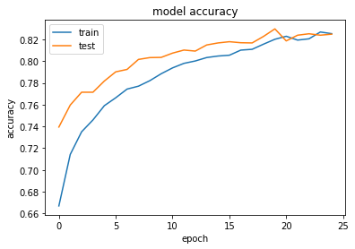

```python
plt.plot(history.history['accuracy'])
plt.plot(history.history['val_accuracy'])
plt.title('model accuracy')
plt.ylabel('accuracy')
plt.xlabel('epoch')
plt.legend(['train', 'test'], loc='upper left')
plt.show()
```

```python
headline = ['nice to meet you, coworkers tell new employee they\'ve studied online for hours']
headline = pd.DataFrame(headline)
headline = preprocessing(headline)

sequences=tokenizer_obj.texts_to_sequences(headline)

headline=pad_sequences(sequences,maxlen=MAX_LEN,truncating='post',padding='post')

sentiment = model2.predict(headline,batch_size=1,verbose = 2)[0]
if(sentiment < 0.1):
    print("Non-sarcastic")
else:
    print("Sarcasm")
```

```
Sarcasm
```

```python
sentiment
```

```
array([0.15185605], dtype=float32)
```

```python
headline = ['Silence is golden. Duct tape is silver.']
headline = pd.DataFrame(headline)
headline = preprocessing(headline)

sequences=tokenizer_obj.texts_to_sequences(headline)

headline=pad_sequences(sequences,maxlen=MAX_LEN,truncating='post',padding='post')

sentiment = model2.predict(headline,batch_size=1,verbose = 2)[0]
if(sentiment < 0.1):
    print("Non-sarcastic")
else:
    print("Sarcasm")
```

```
Sarcasm
```

```python
sentiment
```

```
array([0.13818665], dtype=float32)
```

- with multiple models and results we can observe that increasing the layers not necessarily incresing the prediction capacity but sometimes decreasing it as well if not properly fine tuned.
- We were able to acheieve close to 83% accuracy for test sets.

###### Visualizing the words in the json

```python
!pip install stylecloud
```

```python
import stylecloud
```

```python
stylecloud.gen_stylecloud(file_path='data/Sarcasm_Headlines_Dataset.json',icon_name='fas fa-apple-alt')
```

[figure not shown]

```python
from PIL import Image

Image.open('stylecloud.png')
```